# POLI 110

October 1, 2026

## Objectives

### (1) **Concept Review**

### (2) **Variables and Measures**

### (3) **Variables**

- **Validity**

## An example

[video not shown]

## Example

- What is the “problem” they are trying fix?
- What are some descriptive claims implied by the “problem”
- What do we need to “check” these claims?
- What concepts? Definition?

## Need to use our tools:

**Concepts**: define our terms in a way that is **transparent** and can be used **systematically**. If concepts are opaque or idiosyncratic \(\to\) STOP! (board)

**Variables**: translate concepts into something that we can (in principle) **observe**. If variables do not correspond to the concept / correspond to *other* concepts \(\to\) STOP!

**Measurement**: devise **transparent** and **systematic** procedures with known **uncertainty** to variable in specific cases. If procedure is opaque, suffers from bias, has high uncertainty \(\to\) STOP!

## Defining Misinformation:

“Misinformation is know it when I see it”:

- If I want to show that misinformation has gotten worse… no transparent and systematic definition let’s me label content in line with my claim \(\to\) **fails weak severity**

## Defining Misinformation:

“Misinformation is factually inaccurate information OR whatever is on social media”:

- If I want to show misinformation has gotten worse… absence of systematic definition (loophole for social media) leads me to find more misinformation whenever there is more social media (even if social media content were truthful) \(\to\) **fails weak severity**

## Defining Misinformation:

What is **misinformation**?

- false/factually inaccurate information that may be shared intentionally or unintentionally

What is **disinformation**?

- intentional dissemination of known false/factually inaccurate information

## How is misinformation observable?

How can we **observe** misinformation in a way that lets us evaluate whether:

“Misinformation has become more widespread in recent years.”

How can we **observe** disinformation in a way that lets us evaluate whether:

“Disinformation has become more widespread in recent years.”

- this points us toward **variables** and **measures**

## Variables and Measures

## Variables and Measures:

**variable**: A *measurable* property of cases that corresponds to a **concept** or part of a concept and can *potentially* take on different **values** across cases and time (it *vari*es across cases).

- something we *could* observe **in principle**
- Chosen to indicate membership in category/presence of attribute (concepts)
- take on *values* for cases at a specific point in time
- *Vari*ation across **cases** and/or over **time**.
- General (e.g., “fraction of shared news that is false”, not “fraction of shared news on Facebook in Canada in 2024 that was false.”)

## Variables and Measures:

**measure**: A **procedure** for determining the *value* a variable takes for **specific cases** through **observation**.

- Measures aim to determine the **values** a variable takes for some cases
- Target some some specific cases we want to know about (e.g., a procedure for estimating the fraction of shared news on Facebook in Canada in 2024 that was false.)

## Variables and Measures:

**NOTE**: whats the difference?

Variables can be more or less precise: “level of democracy” vs “ratio of price per area of ads vs classified ads in printed newspapers”

- precise variables may **look** like a measure.
- but measures always say **how** we see something

## A Trivial Example:

**What is the tallest mountain on Earth?**

[figure not shown]

## A Trivial Example:

### **A descriptive question:**

What is the tallest mountain on the North Shore?

### **We need to:**

- define a the **concept** of “tall”
- create a **variable** that matches that definition
- develop a procedure to obtain **values** for mountains on the North Shore (**measure**)

## Concept to Measurement:

### Concept: tallness (of a mountain)

Elevation (distance from peak to sea level)

### \(\xrightarrow{}\) Variable:

Vertical distance in meters from [mean sea level](https://en.wikipedia.org/wiki/Sea_level) to the top of the peak

### \(\xrightarrow{}\) Measure:

Use difference in barometric pressure at Burrard Inlet and peak to calculate difference in elevation

## Concept to Measurement:

[figure not shown]

Are you going to climb the mountain? Prominence might be a better concept of height.

## Concept to Measurement:

### Concept: tallness (of a mountain)

the elevation of a summit relative to the highest point to which one must descend before reascending to a higher summit

### \(\xrightarrow{}\) Variable:

Vertical distance in meters from top of the peak to lowest contour line surrounding it and no other higher peaks.

### \(\xrightarrow{}\) Measure:

Satellites using radar interferometry create topographical maps; computer algorithm to find lowest contour

## Concept to Measurement:

Different concepts \(\to\) different variables

Different variables \(\to\) different measures

Different Answer:

- Using elevation from sea level, West Lion is taller
- Using prominence, Seymour is taller.

## Variables

## Variables: Example 1

**Claim**: “Canadian exposure to misinformation has increased in recent years.”

- What concepts do we need to define?

## Variables: Example 1

**Claim**: “Canadian exposure to misinformation has increased in recent years.”

**Concept**: exposure to misinformation

**Variable**: Proportion of people who believe it is hard for them to distinguish between true and false information.

**Measure**: Ask random sample of Canadians to answer whether they find distinguishing true vs. false information is “harder”, “easier”, or “unchanged” now compared to 3 years ago.

- What values can this variable take? What could go wrong here? (Any risk of incorrectly accepting claim ?)

## Variables: Example 2

**Claim**: “Conservative Twitter/X users are exposed to more misinformation.”

- What concepts do we need to define?

## Variables: Example 2

**Claim**: “Conservative Twitter/X users are exposed to more misinformation.”

**Concept**: **falseness of a message**

**Variable**: rating of a statement on a scale of (True, Mostly True, Half True, Mostly False, False, Pants on Fire)

**Measure**: Ratings of Fact-checked statements on [PolitiFact.com. Methodology Here.](https://www.politifact.com/article/2018/feb/12/principles-truth-o-meter-politifacts-methodology-i/)

- What values can this variable take? What could go wrong here? (Any risk of incorrectly accepting claim ?)

## Variables: Example 2

**Claim**: “Conservative Twitter/X users are exposed to more misinformation.”

**Concept**: **message exposure**

**Variable**: Number of tweets posted by “elite” (e.g., politicians, bureaucrats, famous personalities, advocacy groups, and media organizations) accounts followed by the user

**Measure**: Twitter/X API to find follows, tweets.

- What values can this variable take? What could go wrong here? (Any risk of incorrectly accepting claim ?)

## Variables: Example 2

**Concept**: **exposure to misinformation**

**Variable**: The average falseness of messages by elite (e.g., politicians, bureaucrats, famous personalities, advocacy groups, and media organizations) X users followed by a person, weighted by the number of Tweets made by each elite.

- What could go wrong here?

[Check your “exposure to misinformation” here!](https://misinfoexpose.com/)

## Variables: Example 2

**Claim**: “Conservative Twitter/X users are exposed to more misinformation.”

**Concept**: **political ideology**

**Measure**: Elite accounts labeled with known ideology; users scored by ideology of accounts they follow.

- What values can this variable take? What could go wrong here? (Any risk of incorrectly accepting claim ?)

## Problems

Different issues:

- variables may not capture the concept we want.
- variables may capture OTHER concepts, as well.
- measures may be poor.

## Validity

## Variables can fail:

Even if we develop a concept that is transparent and systematic…

### **variables may not correspond to the concept**

This may mean…

- at best: what we observe is irrelevant.
- at worst: regardless of measurement procedure, we are going to find claim to be true, even when it is not (fails weak severity)

## Variable Trouble: Validity

**validity**: Degree of “fit” between a variables the concept the variable is intended to capture.

- When a variable “captures” or “maps onto” the concept we want to observe in \(\to\) “validity”
- When a variable “captures” or “maps onto” other concepts we do **not want to observe** \(\to\) lack of “validity”
- lack of validity *may* \(\to\) make incorrect conclusions

## Variable Trouble: Validity

In our discussion: some of the concerns were about **measurement**:

How do you know if the problem is with **validity**:

> **even if** we are able to **perfectly observe** (**measure**) something, we think still don’t capture the concept from the claim.

## Variable Trouble: Validity

“State of Bihar isn’t the most politically corrupt in India”

**Concept**: Political Corruption or “the use of power by government officials for illegitimate private gain”

**Variable**: Fraction of political officeholders in a place prosecuted for corruption

**Measure**: Match criminal court defendants in corruption prosecutions to list of politicians.

- What factors influence what we’d see for this variable?

### **Concept**: Political Corruption or “the use of power by government officials for illegitimate private gain”

### **Variable**: Fraction of political officeholders in a place prosecuted for corruption

### **Measure**: Match criminal court defendants in corruption prosecutions to list of politicians.

### Problems

- Places with lots of corruption do not prosecute corruption
- Places with low corruption successfully prosecute corruption
- Places low corruption have stricter corruption laws.
- Yet **measure** will give correct values for the **variable**

(board)

## Variable Trouble: Weak Severity

**Claim**: “The risk of being a victim of a violent crime is less in Canada than the United States”

**Variable**: Number of violent crimes

- What factors influence what we would see with this variable?
- Would using this variable permit us to find the claim wrong? (board)

## Validity

Where do validity problems come from?

- failure to correspond to the concept
- attributes other than our concept affect what we observe.
  - sometimes this is due to wrong level of measurement.

## Wrap up

## Misinformation: Example 1

Stats Canada found that in 2025: 47% of Canadians said “it was … more difficult than it was three years earlier to distinguish between true and false information”

Can we conclude that “misinformation is getting worse”?

## Variables: Example 1

**Claim**: “Canadian exposure to misinformation has increased in recent years.”

**Concept**: exposure to misinformation

**Variable**: Proportion of people who believe it is hard for them to distinguish between true and false information.

**Measure**: Ask random sample of Canadians to answer whether they find distinguishing true vs. false information is “harder”, “easier”, or “unchanged” now compared to 3 years ago.

- Do you have validity concerns here?

## Misinformation: Example 2

[Measuring exposure to misinformation from political elites on Twitter](https://www.nature.com/articles/s41467-022-34769-6)

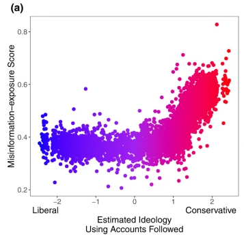

## Misinformation: Example 2

**Concept**: **exposure to misinformation**

**Variable**: The average falseness of messages by elite (e.g., politicians, bureaucrats, famous personalities, advocacy groups, and media organizations) X users followed by a person, weighted by the number of Tweets made by each elite.

- Do you have validity concerns here?

[Check your “exposure to misinformation” here!](https://misinfoexpose.com/)

## Misinformation: Example 2

**Claim**: “Conservative Twitter/X users are exposed to more misinformation.”

**Concept**: **political ideology**

**Measure**: Elite accounts labeled with known ideology; users scored by ideology of accounts they follow.

- Do you have validity concerns here?

## Validity and Strong Severity

It is not enough to just *imagine* that there might be a validity problem:

- either we have strong reasons to think there are obvious problems
- or we need to suggest what we should observe that would rule out the validity concern
- evidence where possible problems with validity are taken seriously and ruled out with other evidence is **stronger** (survived more attempts to find errors)

## Conclusion

1. Distinguish between Variables and Measures
- **variables** are what we **could observe** about cases that matches the concept
- **measures** are procedures to find values of variables for specific cases (data collection)
1. Variables:
- different levels of measurement
- variables may lack **validity**: even if data perfectly captures what we want to observe, our conclusions are flawed
- lack of validity *may* lead to failure to meet weak severity